# Análisis exploratorio: sal_vm_canalX y sal_tx_canalX

Alejandro Bedoya - Sebastián Agudelo - Mateo Espinal - Juan Fernando Patiño - Estefanía Echeverry

Junio - 2021

# 1. Pasos previos al análisis

## 1.1. Se cargan las librerías necesarias

```r
library(dplyr)
library(knitr)
library(kableExtra)
library(ggplot2)
library(ggcorrplot)
library(scales)
library(formattable)
options(scipen = 999)
```

## 1.2. Lectura de la base de datos

```r
#Se carga la base de datos
datos_originales <- read.csv("../datos/base_trabajo_segmentacion.csv",
                             sep = ";")

#Se imprime la cabecera
kable(head(datos_originales), "html", align = "c") %>%
    kable_paper("hover", full_width = F) %>%
    row_spec(0, background = "#327CCF", color = "white")%>%
    scroll_box(width = "100%") %>%
    kable_styling(bootstrap_options = c("hover", "condensed"))
```

| nit | en_vm_canal1 | en_vm_canal2 | en_vm_canal3 | en_vm_canal4 | en_vm_canal5 | en_vm_canal6 | en_vm_canal7 | en_vm_canal8 | en_vm_canal9 | en_vm_canal10 | en_vm_otros | en_tx_canal1 | en_tx_canal2 | en_tx_canal3 | en_tx_canal4 | en_tx_canal5 | en_tx_canal6 | en_tx_canal7 | en_tx_canal8 | en_tx_canal9 | en_tx_canal10 | en_tx_otros | sal_vm_canal5 | sal_vm_canal2 | sal_vm_canal8 | sal_vm_otros | sal_tx_canal5 | sal_tx_canal2 | sal_tx_canal8 | … |
| --- | --- | --- | --- | --- | --- | --- | --- | --- | --- | --- | --- | --- | --- | --- | --- | --- | --- | --- | --- | --- | --- | --- | --- | --- | --- | --- | --- | --- | --- | --- |
| C4936394968152386565 | 0 | 0 | 0 | 0 | 0 | 0 | 0 | 0 | 0 | 0 | 0 | 0.000000 | 0.000000 | 0.000000 | 0.00000 | 0.000000 | 0.00 | 0.00 | 0.0 | 0 | 0 | 0 | 0 | 0 | 0 | 0 | 0.000000 | 0.00000 | 0 | … |
| C-8615176103348111575 | 0 | 0 | 0 | 0 | 0 | 0 | 0 | 0 | 0 | 0 | 0 | 0.000000 | 0.000000 | 0.000000 | 0.00000 | 0.000000 | 0.00 | 0.00 | 0.0 | 0 | 0 | 0 | 0 | 0 | 0 | 0 | 0.000000 | 0.00000 | 0 | … |
| C2364605246729357060 | 250927493 | 54160892 | 5122152 | 41852510 | 413614315 | 1663236 | 2106847525 | 0 | 0 | 0 | 0 | 24.416667 | 11.916667 | 3.333333 | 237.83333 | 2.545454 | 5.40 | 8.25 | 0.0 | 0 | 0 | 0 | 413614315 | 2265361194 | 0 | 0 | 2.545454 | 613.08333 | 0 | … |
| C7393816976826597531 | 39402360 | 96468998 | 8226710 | 0 | 0 | 7072802 | 0 | 9000000 | 0 | 0 | 0 | 14.416667 | 13.833333 | 4.600000 | 0.00000 | 0.000000 | 2.80 | 0.00 | 1.0 | 0 | 0 | 0 | 0 | 60558440 | 0 | 0 | 0.000000 | 10.33333 | 0 | … |
| C872645851723947566 | 337432319 | 234217927 | 105344054 | 15755287 | 0 | 23671840 | 0 | 3600962 | 3727299 | 0 | 0 | 153.583333 | 42.250000 | 102.416667 | 49.33333 | 0.000000 | 18.00 | 0.00 | 2.2 | 4 | 0 | 0 | 0 | 0 | 0 | 622080714 | 0.000000 | 0.00000 | 0 | … |
| C-3870380727390720970 | 33629514 | 42883291 | 1348792 | 0 | 0 | 3828360 | 0 | 0 | 687244 | 0 | 0 | 7.416667 | 8.833333 | 1.000000 | 0.00000 | 0.000000 | 1.25 | 0.00 | 0.0 | 1 | 0 | 0 | 0 | 1960611436 | 0 | 0 | 0.000000 | 90.00000 | 0 | … |

## 1.3. Creación de funciones necesarias

**Función encargada de presentar los resúmenes numéricos**

```r
#Se define la función para presentar los resumenes numéricos
resumen <- function(columna, moneda = TRUE){
    #Se usa la función summary para encontrar los resumenes
    summary_canal <- summary(columna)

    #Se convierte a array y se transpone el resumen numérico
    summary_canal <- t(summary_canal)

    if(moneda == TRUE){

        #Se transforman las cantidades a formato de moneda
        summary_canal <- t(apply(summary_canal, 2, dollar))
    }else{

        #Se crea el fomato numérico para los datos
        numerico <- dollar_format(prefix = "")

        #Se añade separador de miles a las cantidades
        summary_canal <- t(apply(summary_canal, 2, numerico))
    }

    #Se calcula la cantidad de ceros de la variable
    ceros <- sum(columna == 0)

    #Se calcula la proporción de ceros para cada variable
    prop_ceros <- ceros/length(columna)

    #Se convierte la proporción de ceros a escala de porcentaje
    prop_ceros <- round(prop_ceros,4)*100

    #Se añade el simbolo de porcentaje a la proporción de eros
    prop_ceros <- paste0(prop_ceros,"%")

    #Se concatena el resumen numerico con la cantidad y la proporción de ceros
    summary_canal <- cbind(summary_canal, ceros, prop_ceros)

    #Se crean los nombres en español para los resumenes
    nombres_resumen <- c("Mínimo", "Q1", "Mediana", "Media", "Q3",
                         "Máximo", "Ceros", "Proporcion ceros")

    #Se estiliza el resumen con la función kable
    kable(summary_canal, col.names = nombres_resumen, align = "c",  "html") %>%
        #Se utiliza el tema kable_papper
        kable_paper("hover", full_width = TRUE) %>%
        kable_styling(bootstrap_options = c("hover", "condensed"),
                      font_size = 16) %>%
        row_spec(0, background = "#327CCF", color = "white")
}
```

**Función encargada de realizar los histogramas**

```r
#Se crea la función para dibujar los gráficos
crear_grafico <- function(datos, columna, bins=300, numero_columna, vm = TRUE){

    columna = enquo(columna)

    #Se elije el tipo de etiqueta según la variable analizada
    if(vm == TRUE){
        etiqueta <- "valor del ticket"
    }else{
        etiqueta <- "transacciones"
    }

    #Se crea el histograma
    grafico <- ggplot(datos, aes(x = !!columna)) +
        geom_histogram(bins = bins, fill="#327CCF", alpha = 0.4, col = "Black")+
        #Se añade la etiqueta del eje x
        xlab(
            paste(etiqueta,
                  "promedio de salida por el canal",
                  numero_columna)
        ) +
        #Se añade la etiqueta del eje y
        ylab("Frecuencia") +
        #Se añade la etiqueta del titulo
        ggtitle(
            paste("Histograma de",
                  etiqueta,
                  "promedio de salida por el canal",
                  numero_columna)
        ) +
        theme_bw()+
        #Se centra el titulo
        theme(plot.title = element_text(hjust = 0.5))

    return(grafico)
}
```

# 2. Análisis de las variables `sal_vm_canalx`

## 2.1. `sal_vm_canal2`

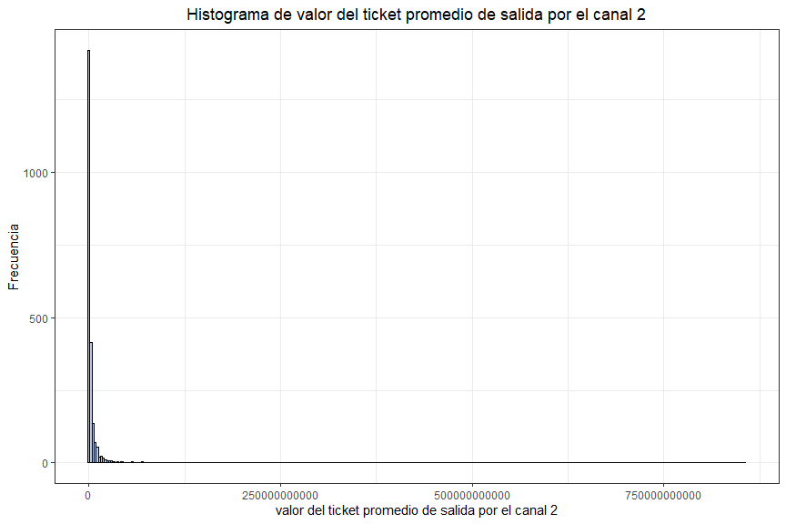

```r
crear_grafico(datos_originales, sal_vm_canal2, bins = 320, numero_columna = 2)
```

```r
resumen(datos_originales$sal_vm_canal2)
```

| Mínimo | Q1 | Mediana | Media | Q3 | Máximo | Ceros | Proporcion ceros |
| --- | --- | --- | --- | --- | --- | --- | --- |
| $0 | $11,397,008 | $660,844,034 | $5,191,256,788 | $2,473,199,364 | $856,183,000,000 | 542 | 24.27% |

Del histograma se resalta que la distribución del valor del ticket promedio de salida por el canal 2 se encuentra altamente sesgada a la derecha, lo cual se evidencia también en el resumen numérico donde la mediana ($660,844,034) se encuentra en la escala de cientos de millones, mientras que la media ($5,191,256,788) se encuentra en la escala de miles de millones, superando no solo el valor de la medida anterior, sino también el del cuartil 3 ($2,473,199,364), indicando la presencia de valores máximos con una escala muy superior a la mayoría de los datos.

Se destaca además que la proporción de entradas en cero (24.27%) es relativamente baja, indicando que es un canal típicamente usado para las salidas y en el cual se manejan grandes valores montários.

## 2.2. `sal_vm_canal5`

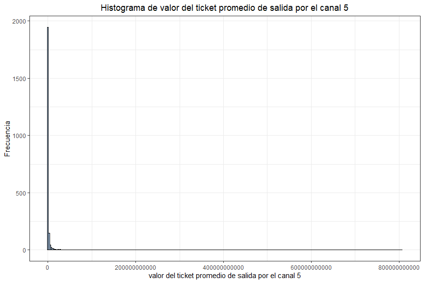

```r
crear_grafico(datos_originales, sal_vm_canal5, bins = 320, numero_columna = 5)
```

```r
resumen(datos_originales$sal_vm_canal5)
```

| Mínimo | Q1 | Mediana | Media | Q3 | Máximo | Ceros | Proporcion ceros |
| --- | --- | --- | --- | --- | --- | --- | --- |
| $0 | $0 | $185,714 | $2,115,933,459 | $300,550,000 | $806,965,000,000 | 1107 | 49.57% |

Del histograma se resalta que la distribución del valor del ticket promedio de salida por el canal 5 se encuentra altamente sesgada a la derecha, lo cual se evidencia también en el resumen numérico donde la mediana ($185,714) se encuentra en una escala demasiado baja en comparació con la media ($2,115,933,459) la cual se sitúa en la escala de miles de millones, superando no solo el valor de la medida anterior, sino también al cuartil 3 ($300,550,000), indicando la presencia de muchos datos en cero y de valores máximos con una escala muy superior a la mayoría de los datos.

Se destaca además que la proporción de entradas en cero (49.57%) es de practicamente el 50%, indicando que es un canal de uso medio, en el cual se manejan grandes valores montários, pero menores en comparación con el canal anterior.

## 2.3. `sal_vm_canal8`

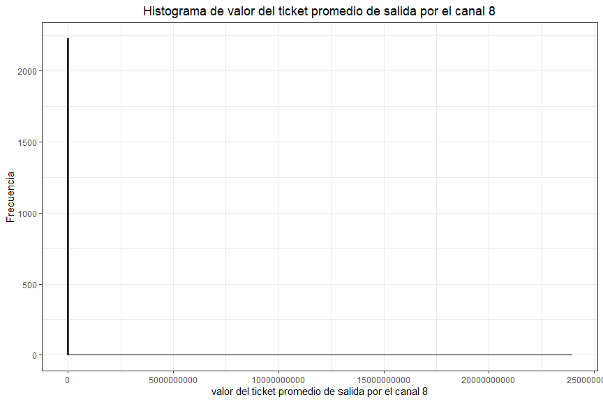

```r
crear_grafico(datos_originales, sal_vm_canal8, bins = 320, numero_columna = 8)
```

```r
resumen(datos_originales$sal_vm_canal8)
```

| Mínimo | Q1 | Mediana | Media | Q3 | Máximo | Ceros | Proporcion ceros |
| --- | --- | --- | --- | --- | --- | --- | --- |
| $0 | $0 | $0 | $12,557,329 | $0 | $23,931,431,000 | 1936 | 86.7% |

Del histograma se resalta que la distribución del valor del ticket promedio de salida por el canal 8 se encuentra extremadamente sesgada a la derecha, lo cual se evidencia también en el resumen numérico donde la mediana ($0) y el cuartil 3 ($0) presentan un valor de cero, con una proporción de entradas en cero (86.7%) demasiado alta, influyendo fuertemente sobre el valor de la media ($12,557,329).

Lo anterior nos muestra el escenario de un canal de poco uso en el que se manejan valores monetarios medianamente bajos, indicando que podría ser restrictivo o poco popular.

## 2.4. `sal_vm_otros`

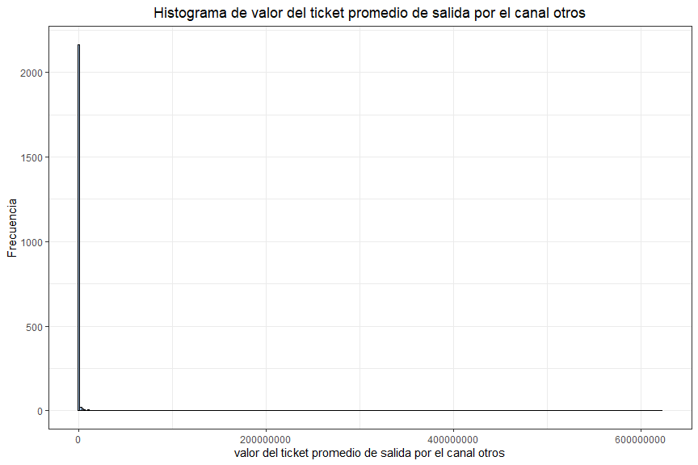

```r
crear_grafico(datos_originales, sal_vm_otros, bins = 320, numero_columna = "otros")
```

```r
resumen(datos_originales$sal_vm_otros)
```

| Mínimo | Q1 | Mediana | Media | Q3 | Máximo | Ceros | Proporcion ceros |
| --- | --- | --- | --- | --- | --- | --- | --- |
| $0 | $0 | $0 | $905,083 | $0 | $622,080,714 | 2147 | 96.15% |

Del histograma se resalta que la distribución del valor del ticket promedio de salida por el canal otros se encuentra extremadamente sesgada a la derecha, lo cual se evidencia también en el resumen numérico donde la mediana ($0) y el cuartil 3 ($0) presentan un valor de cero, con una proporción de entradas en cero (96.15%) supremamente alta, influyendo fuertemente sobre el valor de la media ($905,083).

Lo aterior nos muestra el escenario de un canal de un uso muy limitado, en el que se manejan valores monetarios bajos, indicando que podría ser muy restrictivo, poco popular o exclusivo.

## 2.5. Tabla general de resumenes numéricos

```r
#Se seleccionan las columnas de tipo sal_vm
datos_sal_vm <- datos_originales %>% select(sal_vm_canal2,
                                            sal_vm_canal5,
                                            sal_vm_canal8,
                                            sal_vm_otros)

#Se aplica la función summary a cada columna
resumen_general <- t(apply(datos_sal_vm, 2, function(x){summary(x)}))

#Se convierte el resulado anterior a data frame
resumen_general <- as.data.frame(resumen_general)

#Se convierten las cantidades a formato de moneda
resumen_general <- apply(resumen_general, 2, dollar)

#Se calcula la cantidad de ceros para cada variable
cantidad_ceros <- apply(datos_sal_vm, 2, function(x){sum(x==0)})

#Se calcula la proporción de ceros para cada variable
proporcion_ceros <- apply(datos_sal_vm,
                          2,
                          function(x){
                            p_ceros <- sum(x==0)/length(x)
                            p_ceros <- round(p_ceros ,4)*100
                            paste0(p_ceros, "%")
                            }
                          )

#Se concatene el resumen con la cantidad y la proporción de ceros
resumen_general <- cbind(resumen_general, cantidad_ceros, proporcion_ceros)

#Se crean las etiquetas de la cabecera para los resumenes
nombres_resumen <- c(
  "Mínimo", "Q1", "Mediana", "Media", "Q3", "Máximo", "Ceros", "Proporcion ceros"
  )

#Se muestra la tabla estilizada con la función kable
kable(resumen_general, col.names = nombres_resumen, align = "r") %>%
    kable_paper("hover", full_width = TRUE) %>%
    kable_styling(bootstrap_options = c("hover", "condensed"), font_size = 14) %>%
    row_spec(0, background = "#327CCF", color = "white")
```

|  | Mínimo | Q1 | Mediana | Media | Q3 | Máximo | Ceros | Proporcion ceros |
| --- | --- | --- | --- | --- | --- | --- | --- | --- |
| sal_vm_canal2 | $0 | $11,397,008 | $660,844,034 | $5,191,256,788 | $2,473,199,364 | $856,183,000,000 | 542 | 24.27% |
| sal_vm_canal5 | $0 | $0 | $185,714 | $2,115,933,459 | $300,550,000 | $806,965,000,000 | 1107 | 49.57% |
| sal_vm_canal8 | $0 | $0 | $0 | $12,557,329 | $0 | $23,931,431,000 | 1936 | 86.7% |
| sal_vm_otros | $0 | $0 | $0 | $905,083 | $0 | $622,080,714 | 2147 | 96.15% |

# 3. Análisis de las variables `sal_tx_canalx`

## 3.1. `sal_tx_canal2`

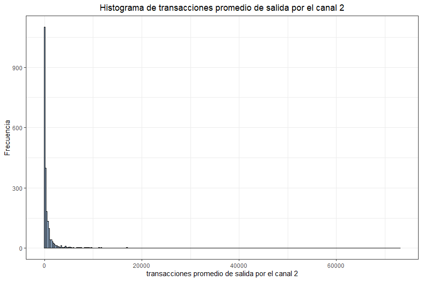

```r
crear_grafico(datos_originales, sal_tx_canal2,
              bins = 320, numero_columna = 2,vm = FALSE)
```

```r
resumen(datos_originales$sal_tx_canal2, moneda = FALSE)
```

| Mínimo | Q1 | Mediana | Media | Q3 | Máximo | Ceros | Proporcion ceros |
| --- | --- | --- | --- | --- | --- | --- | --- |
| 0 | 1 | 122.67 | 763.89 | 561.33 | 73,057.58 | 542 | 24.27% |

Del histograma se resalta que la distribución del número de transacciones promedio de salida por el canal 2 se encuentra altamente sesgada a la derecha, lo cual se refleja en el resumen numérico donde la media (763.89) es mayor a la mediana (122.67) y al cuartil 3 (561.33), indicando la presencia de máximos con valores altos en comparación con el resto de los datos.

Se destaca además que la proporción de entradas en cero (24.27%) es moderadamente baja, indicando que es un canal típicamente usado para las transacciones de salida.

## 3.2. `sal_tx_canal5`

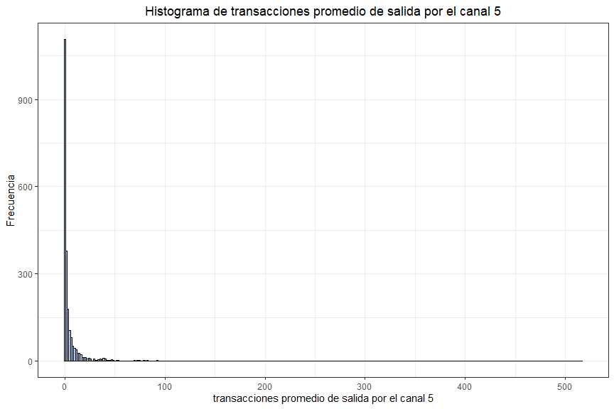

```r
crear_grafico(datos_originales, sal_tx_canal5,
              bins = 320, numero_columna = 5,vm = FALSE)
```

```r
resumen(datos_originales$sal_tx_canal5, moneda = FALSE)
```

| Mínimo | Q1 | Mediana | Media | Q3 | Máximo | Ceros | Proporcion ceros |
| --- | --- | --- | --- | --- | --- | --- | --- |
| 0 | 0 | 1 | 5.70 | 4.17 | 516.50 | 1107 | 49.57% |

Del histograma se resalta que la distribución del número de transacciones promedio de salida por el canal 5 se encuentra altamente sesgada a la derecha, lo cual se evidencia también en el resumen numérico donde la mediana (1) es mas baja que la media (5.70), siendo esta ultima levemente mayor al cuartil 3 (4.17).

Se destaca además que la proporción de entradas en cero (49.57%) es de practicamente el 50%, indicando que es un canal de uso medio, en el cual se manejan un número moderado de transacciones, no superando las 516.50 por cliente.

## 3.3. `sal_tx_canal8`

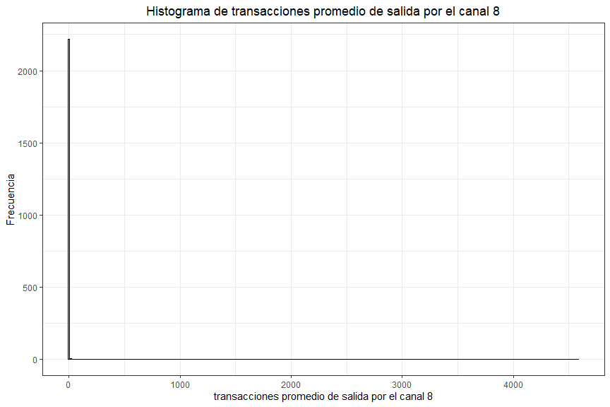

```r
crear_grafico(datos_originales, sal_tx_canal8,
              bins = 320, numero_columna = 8,vm = FALSE)
```

```r
resumen(datos_originales$sal_tx_canal8, moneda = FALSE)
```

| Mínimo | Q1 | Mediana | Media | Q3 | Máximo | Ceros | Proporcion ceros |
| --- | --- | --- | --- | --- | --- | --- | --- |
| 0 | 0 | 0 | 2.47 | 0 | 4,586 | 1936 | 86.7% |

Del histograma se resalta que la distribución del número de transacciones promedio de salida por el canal 8 se encuentra extremadamente sesgada a la derecha, lo cual se evidencia también en el resumen numérico donde la mediana (0) y el cuartil 3 (0) son ambos cero, con una proporción de entradas en cero (86.7%) muy elevada, causando un fuerte impacto sobre la media (2.47).

Lo anterior nos muestra el escenario de un canal de poco uso en el que se manejan en promedio un número moderadamente bajo de transacciones, sin embargo, al presentar un máximo de transacciones alto, se intuye que podría tratarse de un canal restrictivo, exclusivo o de difícil acceso.

## 3.4. `sal_tx_otros`

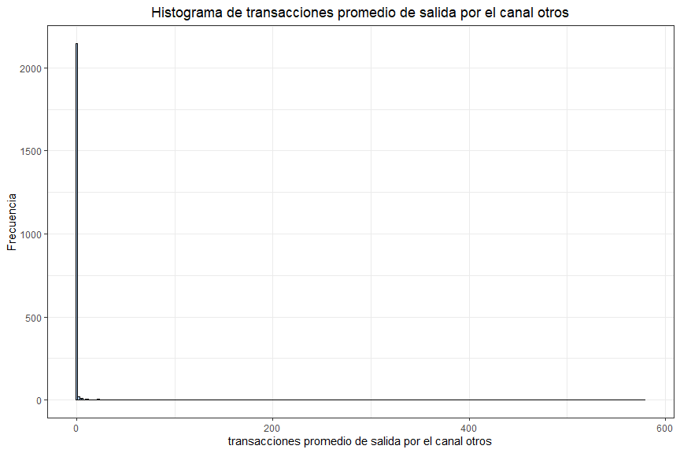

```r
crear_grafico(datos_originales, sal_tx_otros,
              bins = 320, numero_columna = "otros",vm = FALSE)
```

```r
resumen(datos_originales$sal_tx_otros, moneda = FALSE)
```

| Mínimo | Q1 | Mediana | Media | Q3 | Máximo | Ceros | Proporcion ceros |
| --- | --- | --- | --- | --- | --- | --- | --- |
| 0 | 0 | 0 | 0.90 | 0 | 579.21 | 2147 | 96.15% |

Del histograma se resalta que la distribución del número de transacciones promedio de salida por el canal otros se encuentra extremadamente sesgada a la derecha, con un comportamiento muy similar al canal anterior pero con valores menores, donde la mediana (0) y el cuartil 3 (0) son ambos cero, con una proporción de entradas en cero (96.15%) muy elevada, causando un fuerte impacto sobre la media (0.90), la cual es menor a una transacción.

Lo aterior nos muestra el escenario de un canal de un uso muy limitado, en el que se maneja un numero muy bajo de transacciones, indicando que podría ser muy restrictivo, poco popular o exclusivo.

## 3.5. Tabla general de resumenes numéricos

```r
#Se seleccionan las columnas de tipo sal_tx
datos_sal_tx <- datos_originales %>% select(sal_tx_canal2,
                                            sal_tx_canal5,
                                            sal_tx_canal8,
                                            sal_tx_otros)

#Se aplica la función summary a cada columna
resumen_general <- t(apply(datos_sal_tx, 2, function(x){summary(x)}))

#Se convierte el resulado anterior a data frame
resumen_general <- as.data.frame(resumen_general)

#Se crea el formato numerico para los datos
numerico <- dollar_format(prefix = "")

#Se convierten las cantidades a formato numerico
resumen_general <- apply(resumen_general, 2, numerico)

#Se calcula la cantidad de ceros para cada variable
cantidad_ceros <- apply(datos_sal_tx, 2, function(x){sum(x==0)})

#Se calcula la proporción de ceros para cada variable
proporcion_ceros <- apply(datos_sal_tx,
                          2,
                          function(x){
                            p_ceros <- sum(x==0)/length(x)
                            p_ceros <- round(p_ceros ,4)*100
                            paste0(p_ceros, "%")
                            }
                          )

#Se concatene el resumen con la cantidad y la proporción de ceros
resumen_general <- cbind(resumen_general, cantidad_ceros, proporcion_ceros)

#Se crean las etiquetas de la cabecera para los resumenes
nombres_resumen <- c(
  "Mínimo", "Q1", "Mediana", "Media", "Q3", "Máximo", "Ceros", "Proporcion ceros"
  )

#Se muestra la tabla estilizada con la función kable
kable(resumen_general, col.names = nombres_resumen, align = "r") %>%
    kable_paper("hover", full_width = TRUE) %>%
    kable_styling(bootstrap_options = c("hover", "condensed"), font_size = 14) %>%
    row_spec(0, background = "#327CCF", color = "white")
```

|  | Mínimo | Q1 | Mediana | Media | Q3 | Máximo | Ceros | Proporcion ceros |
| --- | --- | --- | --- | --- | --- | --- | --- | --- |
| sal_tx_canal2 | 0 | 1 | 122.67 | 763.89 | 561.33 | 73,057.58 | 542 | 24.27% |
| sal_tx_canal5 | 0 | 0 | 1.00 | 5.70 | 4.17 | 516.50 | 1107 | 49.57% |
| sal_tx_canal8 | 0 | 0 | 0.00 | 2.47 | 0.00 | 4,586.00 | 1936 | 86.7% |
| sal_tx_otros | 0 | 0 | 0.00 | 0.90 | 0.00 | 579.21 | 2147 | 96.15% |

# 4. Correlación entre las variables

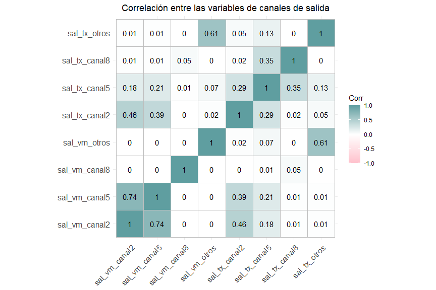

```r
#Se calulan las correlaciones entre las variables
correlaciones <- cor(cbind(datos_sal_vm,datos_sal_tx))

#Se muestra el gráfico de correlación
ggcorrplot(correlaciones, lab = TRUE, colors = c("pink",
                                                 "white",
                                                 "cadetblue")
)+
  #Se añade el titulo del gráfico
  ggtitle("Correlación entre las variables de canales de salida")+
  #Se centra el titulo
  theme(plot.title = element_text(hjust = 0.5))
```